# Pre-Workshop Survey Results

R Pruim

5/24/2019

Number of surveys completed: 32

### Demographics

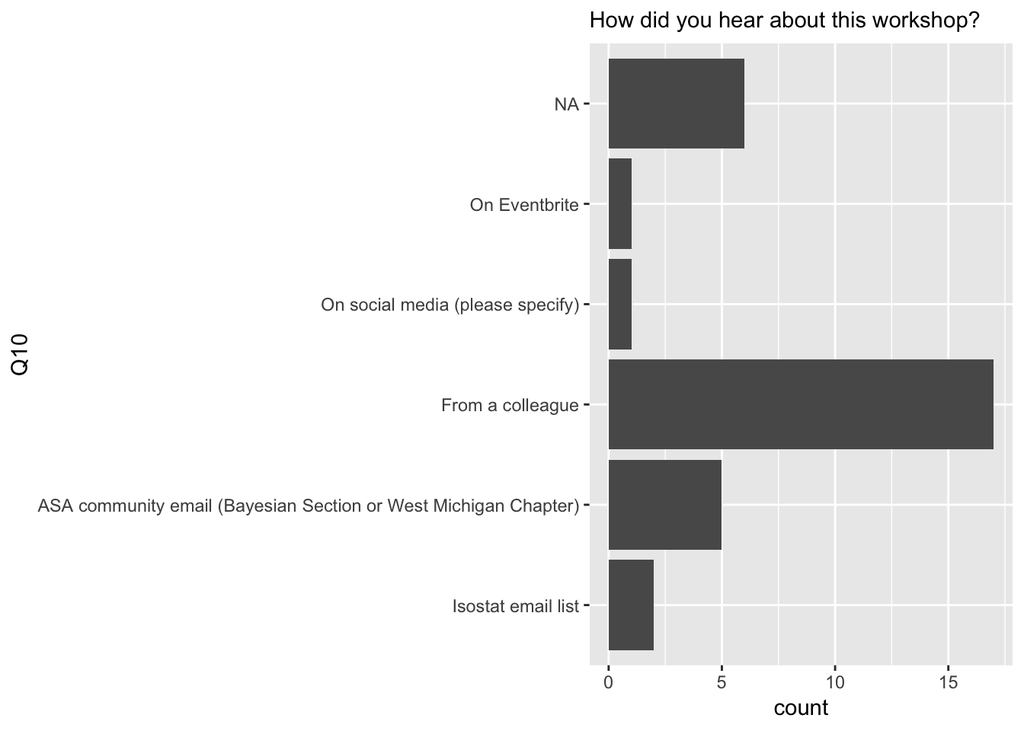

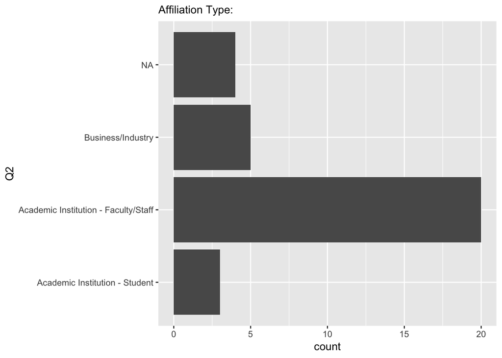

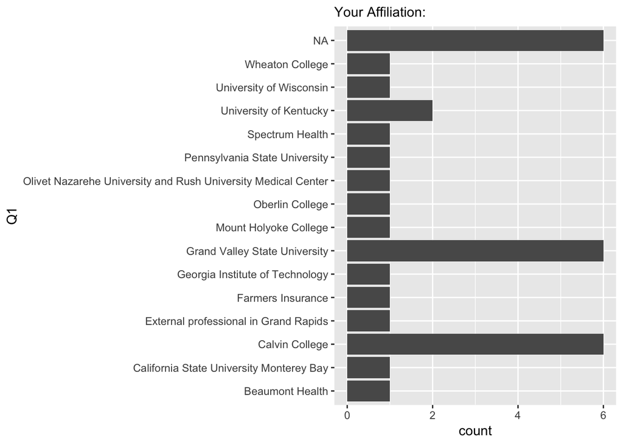

### Background/Interests

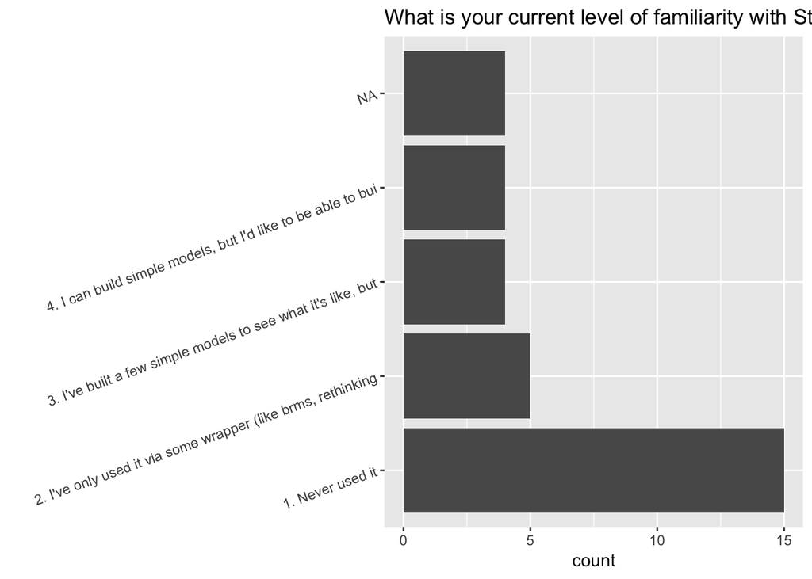

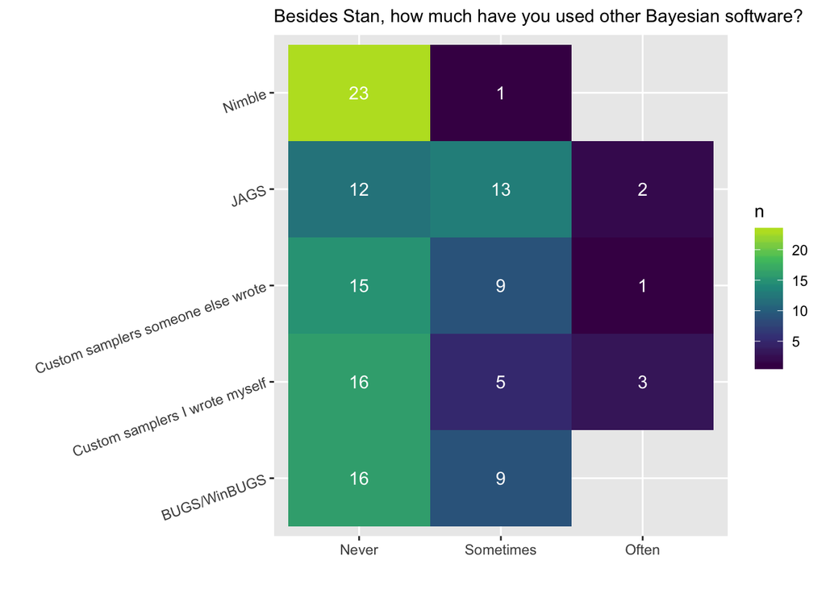

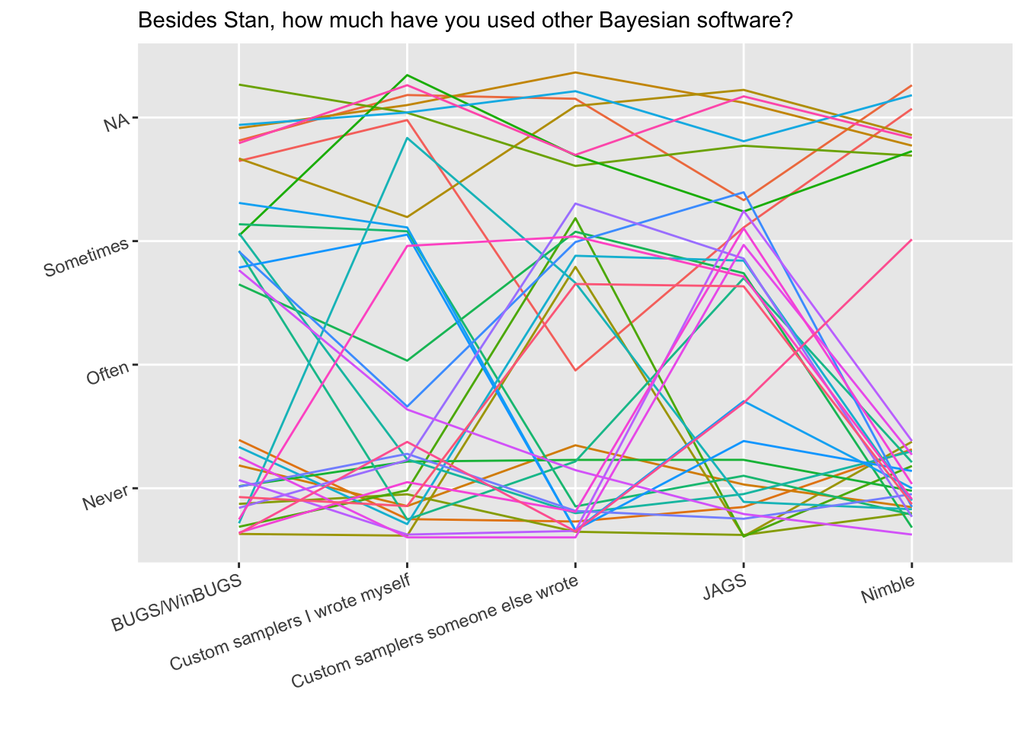

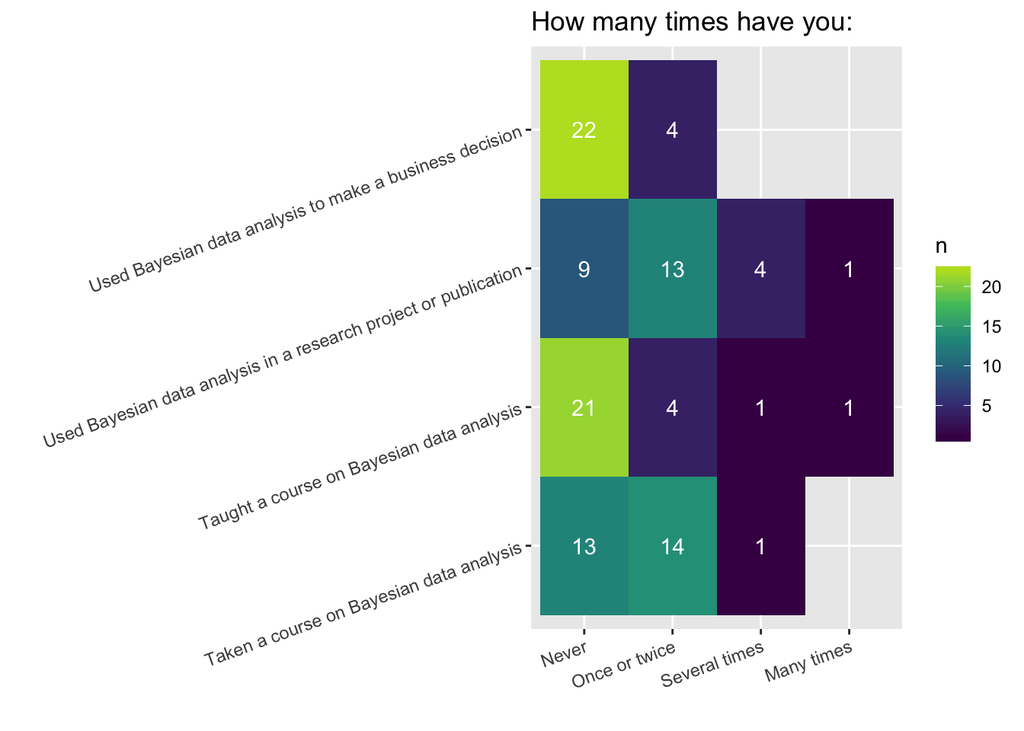

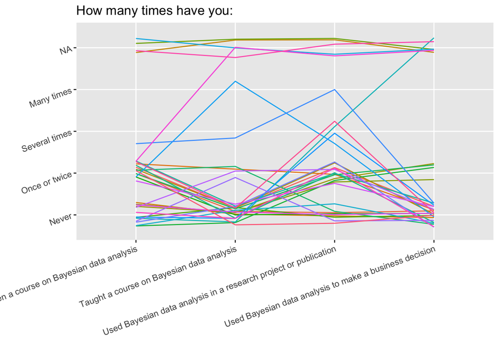

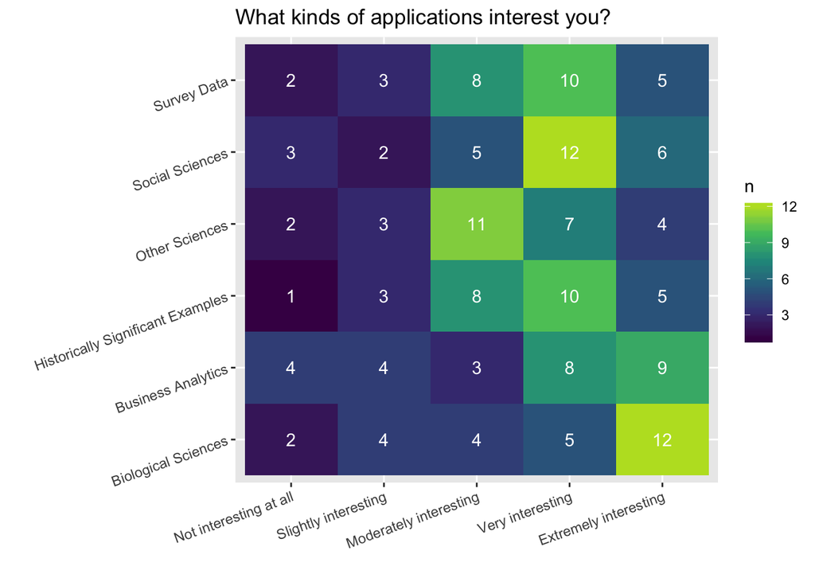

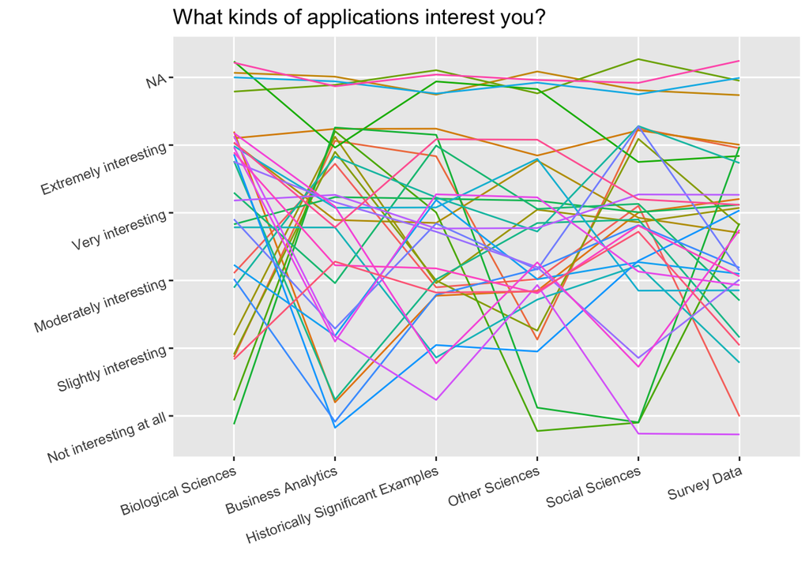

### Challenges

For you, what has been the most difficult/frustrating part about using Stan?

[[1]]

probably debugging in terms of initialization of variables - that has thrown me a number of times

### Goals

[[1]]

Learn more about best ways to present models to Stan; diagnose models and their fits in Stan; best tools for working stan models in R post-fit; good examples for classes; good work-flow practices for Bayesian modeling in Stan/R.

[[2]]

1. To obtain knowledge about the fundamental building blocks of Bayesian Data Analysis.\2. To gain practical experience about how to solve business analytics problems using probabilistic programming in R & Stan.\3. To develop relationships with students, professionals, and scholars working in the field of Bayesian data analysis.

[[3]]

I am primarily interested into learning more about STAN and its appropriate application in Bayesian statistics.

[[4]]

I’ve done some Bayesian modeling in the past and now my research has taken a turn in needing those methods again. I’ve used winbugs but I am rusty and I want to get more current in my tech with stan

[[5]]

I am teaching a Bayesian class in the fall and am on a grant where I am planning on using hierarchical models with Bayesian model fits. I would like to get ‘tooled up’ on running more complex models in stan with a very FIRM grasp on building models (including appropriate priors and initialization values), debugging (including best practices), and model assessment (all of this with lots of good examples to work with). And having good documentation with those examples (that has been frustrating at times with stan) would be very helpful.

[[6]]

Learn about STAN and update my understanding of Bayesian data analysis.

[[7]]

I’m very comfortable in R, but have coded my own samplers for teaching and research. I’ve never used STAN but would like to learn!

[[8]]

Just get started with Stan.

[[9]]

Learn about Stan, evaluating its utility for teaching my graduate courses

[[10]]

Prime and catalyze further familiarization with Bayesian methods.Stan software

[[11]]

Increasing my familiarity with Bayesian statistics and increasing my understanding on how Stan works.

[[12]]

I would like to learn about STAN to help further my own research and to use it in future undergraduate courses in modeling.

[[13]]

Refresher in Bayesian concepts and analysisto use Stan so that I can employ Bayesian analysis in the future

[[14]]

To learn STAN in hopes to use Pystan to compare to PYMC3.

[[15]]

An understanding of how to use Stan on a rather basic level for now. I also am interested in seeing Stan and Bayesian techniques used in real examples that I can take back to enhance teaching.

[[16]]

I’m interested in being introduced to STAN and having a refresher in Bayesian analysis, seeing if there have been new developments since I studied it about 10 years ago.

[[17]]

I hope to come out with the wisdom to know when STAN is the right tool for a modeling job, and to be familiar enough with what it has to offer and how to use it that I can save time and energy by using it instead of writing sampling code myself.\I am also interested in learning how to leverage parallel processing resources when performing inference in STAN.

[[18]]

Very interested in building system and process simulations of social systems (e.g., the Michigan Department of Corrections) using beta distributions to represent the shape of failure risk (from resilience to fragility) within individual simulated people, organizations, and subsystems. For example, if the horizontal axis is the cost of failure, ranging from “low or trivial” to “high or catastrophic,” then a right-skewed distribution would represent a very *fragile* person or entity with a high risk of catastrophic failure (disease in a medical setting, violent behavior in a prison, dropping out in a school), while a left-skewed distribution would describe a resilient entity with a high risk of low-cost failure that yields opportunities for learning without self-destruction.

[[19]]

I’m interested in learning more/gaining practice in the areas listed in the stated goals of the workshop:'Workshop sessions will include information on designing models, choosing priors, describing models in the Stan language, detecting and addressing potential problems with the HMC sampler, and interpreting results. ’

[[20]]

Develop familiarity with these programs to complement self study in Bayesian statistics (I’m trying to shift to this approach as much as reasonable).

[[21]]

Gaining a good working knowledge of Stan. Determining how to best introduce it when teaching courses.

[[22]]

More exposure to basic Bayesian stats methods.

### Dietary Restrictions

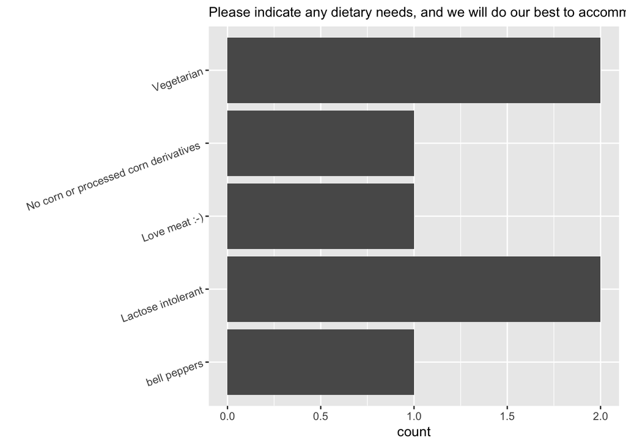

```
## # A tibble: 7 x 3
##   name          email             dietary
##   <chr>         <chr>             <chr>
## 1 Randall Pruim rpruim@calvin.edu Allergy (please indicate) bell peppers
## 2 ADEDAPO ODEY… blacng@gmail.com  Vegetarian
## 3 Stacy DeRuit… sld33@calvin.edu  Vegetarian
## 4 Judith Canner jcanner@csumb.edu Lactose intolerant
## 5 Paul Stephen… stephenp@gvsu.edu Other (please indicate) Love meat :-)
## 6 Neil Carlson  nec4@calvin.edu   "Allergy (please indicate) No corn or pr…
## 7 TREVOR H PARK trevorhpark@yaho… Lactose intolerant
```